# Trade & Ahead

## Problem Statement

### Context

The stock market has consistently proven to be a good place to invest in and save for the future. There are a lot of compelling reasons to invest in stocks. It can help in fighting inflation, create wealth, and also provides some tax benefits. Good steady returns on investments over a long period of time can also grow a lot more than seems possible. Also, thanks to the power of compound interest, the earlier one starts investing, the larger the corpus one can have for retirement. Overall, investing in stocks can help meet life's financial aspirations.

It is important to maintain a diversified portfolio when investing in stocks in order to maximise earnings under any market condition. Having a diversified portfolio tends to yield higher returns and face lower risk by tempering potential losses when the market is down. It is often easy to get lost in a sea of financial metrics to analyze while determining the worth of a stock, and doing the same for a multitude of stocks to identify the right picks for an individual can be a tedious task. By doing a cluster analysis, one can identify stocks that exhibit similar characteristics and ones which exhibit minimum correlation. This will help investors better analyze stocks across different market segments and help protect against risks that could make the portfolio vulnerable to losses.

### Objective

Trade&Ahead is a financial consultancy firm who provide their customers with personalized investment strategies. They have consulted me as a Data Scientist and provided me with data comprising stock price and some financial indicators for a few companies listed under the New York Stock Exchange. My task is to analyze the data, group the stocks based on the attributes provided, and share insights about the characteristics of each group.

### Data Dictionary

- Ticker Symbol: An abbreviation used to uniquely identify publicly traded shares of a particular stock on a particular stock market
- Company: Name of the company
- GICS Sector: The specific economic sector assigned to a company by the Global Industry Classification Standard (GICS) that best defines its business operations
- GICS Sub Industry: The specific sub-industry group assigned to a company by the Global Industry Classification Standard (GICS) that best defines its business operations
- Current Price: Current stock price in dollars
- Price Change: Percentage change in the stock price in 13 weeks
- Volatility: Standard deviation of the stock price over the past 13 weeks
- ROE: A measure of financial performance calculated by dividing net income by shareholders' equity (shareholders' equity is equal to a company's assets minus its debt)
- Cash Ratio: The ratio of a company's total reserves of cash and cash equivalents to its total current liabilities
- Net Cash Flow: The difference between a company's cash inflows and outflows (in dollars)
- Net Income: Revenues minus expenses, interest, and taxes (in dollars)
- Earnings Per Share: Company's net profit divided by the number of common shares it has outstanding (in dollars)
- Estimated Shares Outstanding: Company's stock currently held by all its shareholders
- P/E Ratio: Ratio of the company's current stock price to the earnings per share
- P/B Ratio: Ratio of the company's stock price per share by its book value per share (book value of a company is the net difference between that company's total assets and total liabilities)

## Importing necessary libraries and data

```python
# Installing the libraries with the specified version.
# uncomment and run the following line if Google Colab is being used
# !pip install scikit-learn==1.2.2 seaborn==0.13.1 matplotlib==3.7.1 numpy==1.25.2 pandas==1.5.3 yellowbrick==1.5 -q --user
```

```python
# Installing the libraries with the specified version.
# uncomment and run the following lines if Jupyter Notebook is being used
# !pip install scikit-learn==1.2.2 seaborn==0.13.1 matplotlib==3.7.1 numpy==1.25.2 pandas==1.5.2 yellowbrick==1.5 -q --user
# !pip install --upgrade -q jinja2
```

**Note**: *After running the above cell, kindly restart the notebook kernel and run all cells sequentially from the start again.*

```python
# Libraries to help with reading and manipulating data
import numpy as np
import pandas as pd

# Libraries to help with data visualization
import matplotlib.pyplot as plt
import seaborn as sns

sns.set_theme(style='darkgrid')

# Removes the limit for the number of displayed columns
pd.set_option("display.max_columns", None)
# Sets the limit for the number of displayed rows
pd.set_option("display.max_rows", 200)

# to scale the data using z-score
from sklearn.preprocessing import StandardScaler

# to compute distances
from scipy.spatial.distance import cdist, pdist

# to perform k-means clustering and compute silhouette scores
from sklearn.cluster import KMeans
from sklearn.metrics import silhouette_score

# to visualize the elbow curve and silhouette scores
from yellowbrick.cluster import KElbowVisualizer, SilhouetteVisualizer

# to perform hierarchical clustering, compute cophenetic correlation, and create dendrograms
from sklearn.cluster import AgglomerativeClustering
from scipy.cluster.hierarchy import dendrogram, linkage, cophenet

# to suppress warnings
import warnings
warnings.filterwarnings("ignore")
```

## Loading the Dataset

```python
from google.colab import drive
drive.mount('/content/drive')
```

```python
data = pd.read_csv('/content/drive/MyDrive/content/stock_data.csv')
```

## Data Overview

- Observations
- Sanity checks

### Data Shape

```python
print(f"There are {data.shape[0]} rows and {data.shape[1]} columns.")
```

```
There are 340 rows and 15 columns.
```

### Displaying few rows of the dataset

```python
data.sample(n=10, random_state=1)
```

|  | Ticker Symbol | Security | GICS Sector | GICS Sub Industry | Current Price | Price Change | Volatility | ROE | Cash Ratio | Net Cash Flow | Net Income | Earnings Per Share | Estimated Shares Outstanding | P/E Ratio | P/B Ratio |
| --- | --- | --- | --- | --- | --- | --- | --- | --- | --- | --- | --- | --- | --- | --- | --- |
| 102 | DVN | Devon Energy Corp. | Energy | Oil & Gas Exploration & Production | 32.000000 | -15.478079 | 2.923698 | 205 | 70 | 830000000 | -14454000000 | -35.55 | 4.065823e+08 | 93.089287 | 1.785616 |
| 125 | FB | Facebook | Information Technology | Internet Software & Services | 104.660004 | 16.224320 | 1.320606 | 8 | 958 | 592000000 | 3669000000 | 1.31 | 2.800763e+09 | 79.893133 | 5.884467 |
| 11 | AIV | Apartment Investment & Mgmt | Real Estate | REITs | 40.029999 | 7.578608 | 1.163334 | 15 | 47 | 21818000 | 248710000 | 1.52 | 1.636250e+08 | 26.335526 | -1.269332 |
| 248 | PG | Procter & Gamble | Consumer Staples | Personal Products | 79.410004 | 10.660538 | 0.806056 | 17 | 129 | 160383000 | 636056000 | 3.28 | 4.913916e+08 | 24.070121 | -2.256747 |
| 238 | OXY | Occidental Petroleum | Energy | Oil & Gas Exploration & Production | 67.610001 | 0.865287 | 1.589520 | 32 | 64 | -588000000 | -7829000000 | -10.23 | 7.652981e+08 | 93.089287 | 3.345102 |
| 336 | YUM | Yum! Brands Inc | Consumer Discretionary | Restaurants | 52.516175 | -8.698917 | 1.478877 | 142 | 27 | 159000000 | 1293000000 | 2.97 | 4.353535e+08 | 17.682214 | -3.838260 |
| 112 | EQT | EQT Corporation | Energy | Oil & Gas Exploration & Production | 52.130001 | -21.253771 | 2.364883 | 2 | 201 | 523803000 | 85171000 | 0.56 | 1.520911e+08 | 93.089287 | 9.567952 |
| 147 | HAL | Halliburton Co. | Energy | Oil & Gas Equipment & Services | 34.040001 | -5.101751 | 1.966062 | 4 | 189 | 7786000000 | -671000000 | -0.79 | 8.493671e+08 | 93.089287 | 17.345857 |
| 89 | DFS | Discover Financial Services | Financials | Consumer Finance | 53.619999 | 3.653584 | 1.159897 | 20 | 99 | 2288000000 | 2297000000 | 5.14 | 4.468872e+08 | 10.431906 | -0.375934 |
| 173 | IVZ | Invesco Ltd. | Financials | Asset Management & Custody Banks | 33.480000 | 7.067477 | 1.580839 | 12 | 67 | 412000000 | 968100000 | 2.26 | 4.283628e+08 | 14.814159 | 4.218620 |

### Checking data types

```python
data.info()
```

```
<class 'pandas.core.frame.DataFrame'>
RangeIndex: 340 entries, 0 to 339
Data columns (total 15 columns):
 #   Column                        Non-Null Count  Dtype
---  ------                        --------------  -----
 0   Ticker Symbol                 340 non-null    object
 1   Security                      340 non-null    object
 2   GICS Sector                   340 non-null    object
 3   GICS Sub Industry             340 non-null    object
 4   Current Price                 340 non-null    float64
 5   Price Change                  340 non-null    float64
 6   Volatility                    340 non-null    float64
 7   ROE                           340 non-null    int64
 8   Cash Ratio                    340 non-null    int64
 9   Net Cash Flow                 340 non-null    int64
 10  Net Income                    340 non-null    int64
 11  Earnings Per Share            340 non-null    float64
 12  Estimated Shares Outstanding  340 non-null    float64
 13  P/E Ratio                     340 non-null    float64
 14  P/B Ratio                     340 non-null    float64
dtypes: float64(7), int64(4), object(4)
memory usage: 40.0+ KB
```

**Observations:**

- There are 4 columns as Object type. These will be changed to categorical.

### Checking for duplicates and missing values

```python
data.duplicated().sum()
```

```
0
```

**Observations:**

- There are no duplicated values in the Dataset

```python
data.isna().sum()
```

|  | 0 |
| --- | --- |
| Ticker Symbol | 0 |
| Security | 0 |
| GICS Sector | 0 |
| GICS Sub Industry | 0 |
| Current Price | 0 |
| Price Change | 0 |
| Volatility | 0 |
| ROE | 0 |
| Cash Ratio | 0 |
| Net Cash Flow | 0 |
| Net Income | 0 |
| Earnings Per Share | 0 |
| Estimated Shares Outstanding | 0 |
| P/E Ratio | 0 |
| P/B Ratio | 0 |

**dtype:** int64

**Observations:**

- There are no null values in the Dataset

### Statistical summary of the dataset

```python
data.describe(include='all').T
```

|  | count | unique | top | freq | mean | std | min | 25% | 50% | 75% | max |
| --- | --- | --- | --- | --- | --- | --- | --- | --- | --- | --- | --- |
| Ticker Symbol | 340 | 340 | AAL | 1 | NaN | NaN | NaN | NaN | NaN | NaN | NaN |
| Security | 340 | 340 | American Airlines Group | 1 | NaN | NaN | NaN | NaN | NaN | NaN | NaN |
| GICS Sector | 340 | 11 | Industrials | 53 | NaN | NaN | NaN | NaN | NaN | NaN | NaN |
| GICS Sub Industry | 340 | 104 | Oil & Gas Exploration & Production | 16 | NaN | NaN | NaN | NaN | NaN | NaN | NaN |
| Current Price | 340.0 | NaN | NaN | NaN | 80.862345 | 98.055086 | 4.5 | 38.555 | 59.705 | 92.880001 | 1274.949951 |
| Price Change | 340.0 | NaN | NaN | NaN | 4.078194 | 12.006338 | -47.129693 | -0.939484 | 4.819505 | 10.695493 | 55.051683 |
| Volatility | 340.0 | NaN | NaN | NaN | 1.525976 | 0.591798 | 0.733163 | 1.134878 | 1.385593 | 1.695549 | 4.580042 |
| ROE | 340.0 | NaN | NaN | NaN | 39.597059 | 96.547538 | 1.0 | 9.75 | 15.0 | 27.0 | 917.0 |
| Cash Ratio | 340.0 | NaN | NaN | NaN | 70.023529 | 90.421331 | 0.0 | 18.0 | 47.0 | 99.0 | 958.0 |
| Net Cash Flow | 340.0 | NaN | NaN | NaN | 55537620.588235 | 1946365312.175789 | -11208000000.0 | -193906500.0 | 2098000.0 | 169810750.0 | 20764000000.0 |
| Net Income | 340.0 | NaN | NaN | NaN | 1494384602.941176 | 3940150279.327937 | -23528000000.0 | 352301250.0 | 707336000.0 | 1899000000.0 | 24442000000.0 |
| Earnings Per Share | 340.0 | NaN | NaN | NaN | 2.776662 | 6.587779 | -61.2 | 1.5575 | 2.895 | 4.62 | 50.09 |
| Estimated Shares Outstanding | 340.0 | NaN | NaN | NaN | 577028337.75403 | 845849595.417695 | 27672156.86 | 158848216.1 | 309675137.8 | 573117457.325 | 6159292035.0 |
| P/E Ratio | 340.0 | NaN | NaN | NaN | 32.612563 | 44.348731 | 2.935451 | 15.044653 | 20.819876 | 31.764755 | 528.039074 |
| P/B Ratio | 340.0 | NaN | NaN | NaN | -1.718249 | 13.966912 | -76.119077 | -4.352056 | -1.06717 | 3.917066 | 129.064585 |

**Observations:**

- All values are present.

### Creating a copy of the Dataset

```python
df = data.copy()
```

### Convert all object type columns to category

```python
df = df.apply(lambda col: col.astype('category') if col.dtype == 'object' else col)
```

```python
df.info()
```

```
<class 'pandas.core.frame.DataFrame'>
RangeIndex: 340 entries, 0 to 339
Data columns (total 15 columns):
 #   Column                        Non-Null Count  Dtype
---  ------                        --------------  -----
 0   Ticker Symbol                 340 non-null    category
 1   Security                      340 non-null    category
 2   GICS Sector                   340 non-null    category
 3   GICS Sub Industry             340 non-null    category
 4   Current Price                 340 non-null    float64
 5   Price Change                  340 non-null    float64
 6   Volatility                    340 non-null    float64
 7   ROE                           340 non-null    int64
 8   Cash Ratio                    340 non-null    int64
 9   Net Cash Flow                 340 non-null    int64
 10  Net Income                    340 non-null    int64
 11  Earnings Per Share            340 non-null    float64
 12  Estimated Shares Outstanding  340 non-null    float64
 13  P/E Ratio                     340 non-null    float64
 14  P/B Ratio                     340 non-null    float64
dtypes: category(4), float64(7), int64(4)
memory usage: 58.1 KB
```

## Exploratory Data Analysis (EDA)

- EDA is an important part of any project involving data.
- It is important to investigate and understand the data better before building a model with it.
- A few questions have been mentioned below which will help you approach the analysis in the right manner and generate insights from the data.
- A thorough analysis of the data, in addition to the questions mentioned below, should be done.

**Questions**:

1. What does the distribution of stock prices look like?
2. The stocks of which economic sector have seen the maximum price increase on average?
3. How are the different variables correlated with each other?
4. Cash ratio provides a measure of a company's ability to cover its short-term obligations using only cash and cash equivalents. How does the average cash ratio vary across economic sectors?
5. P/E ratios can help determine the relative value of a company's shares as they signify the amount of money an investor is willing to invest in a single share of a company per dollar of its earnings. How does the P/E ratio vary, on average, across economic sectors?

### Global Functions

```python
def histogram_boxplot(df, feature, figsize=(12, 7), kde=False, bins=None):
    """
    Boxplot and histogram combined

    data: dataframe
    feature: dataframe column
    figsize: size of figure (default (12,7))
    kde: whether to the show density curve (default False)
    bins: number of bins for histogram (default None)
    """
    f2, (ax_box2, ax_hist2) = plt.subplots(
        nrows=2,  # Number of rows of the subplot grid= 2
        sharex=True,  # x-axis will be shared among all subplots
        gridspec_kw={"height_ratios": (0.25, 0.75)},
        figsize=figsize,
    )  # creating the 2 subplots
    sns.boxplot(
        data=df, x=feature, ax=ax_box2, showmeans=True, color="lightblue"
    )  # boxplot will be created and a star will indicate the mean value of the column
    sns.histplot(
        data=df, x=feature, kde=kde, ax=ax_hist2, bins=bins, palette="winter"
    ) if bins else sns.histplot(
        data=df, x=feature, kde=kde, ax=ax_hist2
    )  # For histogram
    ax_hist2.axvline(
        df[feature].mean(), color="green", linestyle="--"
    )  # Add mean to the histogram
    ax_hist2.axvline(
        df[feature].median(), color="black", linestyle="-"
    )  # Add median to the histogram
```

```python
def labeled_barplot(data, feature, perc=False, n=None):
    """
    Barplot with percentage at the top

    data: dataframe
    feature: dataframe column
    perc: whether to display percentages instead of count (default is False)
    n: displays the top n category levels (default is None, i.e., display all levels)
    """

    total = len(data[feature])  # length of the column
    count = data[feature].nunique()
    if n is None:
        plt.figure(figsize=(count + 1, 5))
    else:
        plt.figure(figsize=(n + 1, 5))

    plt.xticks(rotation=90, fontsize=15)
    ax = sns.countplot(
        data=data,
        x=feature,
        order=data[feature].value_counts().index[:n].sort_values(),
    )

    for p in ax.patches:
        if perc == True:
            label = "{:.1f}%".format(
                100 * p.get_height() / total
            )  # percentage of each class of the category
        else:
            label = p.get_height()  # count of each level of the category

        x = p.get_x() + p.get_width() / 2  # width of the plot
        y = p.get_height()  # height of the plot

        ax.annotate(
            label,
            (x, y),
            ha="center",
            va="center",
            size=12,
            xytext=(0, 5),
            textcoords="offset points",
        )  # annotate the percentage

    plt.show()  # show the plot
```

### Univariate Analysis

#### **`Current Price`**

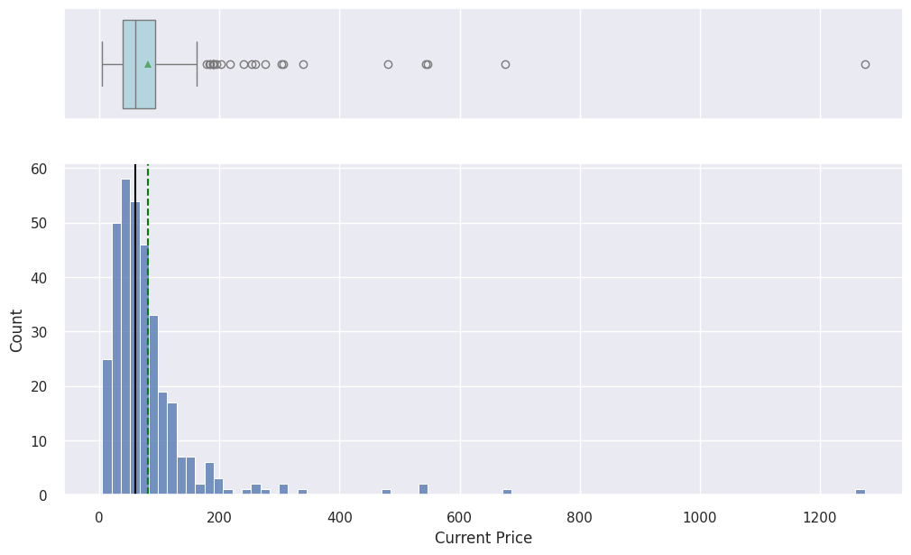

```python
histogram_boxplot(df, 'Current Price')
```

**Observations:**

- Current price is skewed to the right with few outliers in it. The ones detected will be kept since it seems to bring value to the data

#### **`Price Change`**

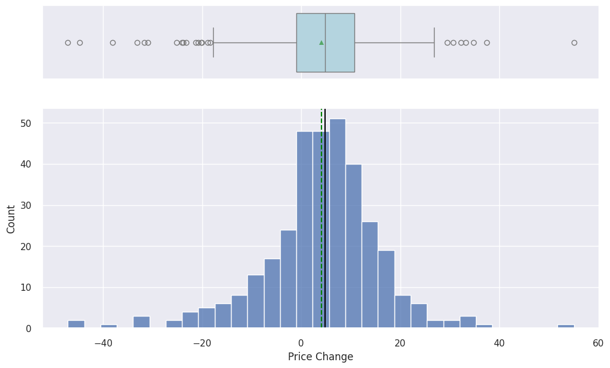

```python
histogram_boxplot(df, 'Price Change')
```

**Observations:**

- Price change follows a normal distribution with some outliers that will be kept as the bring value to the analysis.

#### **`Volatility`**

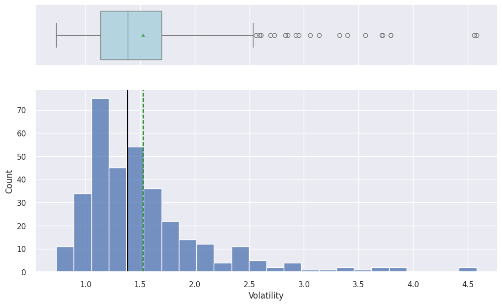

```python
histogram_boxplot(df, 'Volatility')
```

**Observations:**

- Volatility change follows a normal with slight skeweness to the right. It has some outliers that will be kept as the bring value to the analysis.

#### **`ROE`**

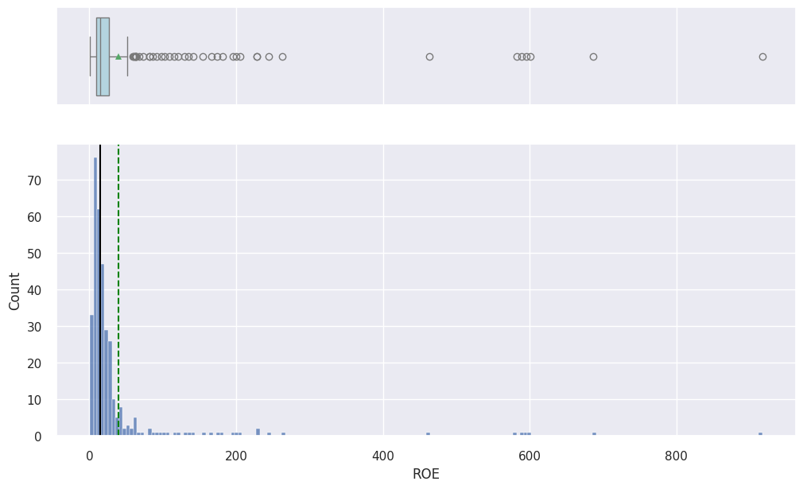

```python
histogram_boxplot(df, 'ROE')
```

**Observations:**

- ROE is fully skewed to the right. there are some outliers not affecting heavily the analysis.

#### **`Cash Ratio`**

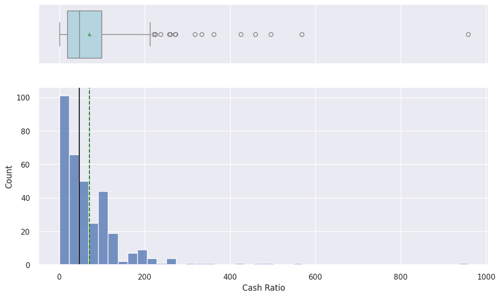

```python
histogram_boxplot(df, 'Cash Ratio')
```

**Observations:**

- Cash ratio is skewed to the right. There are some outliers not affecting heavily the analysis.

#### **`Net Cash Flow`**

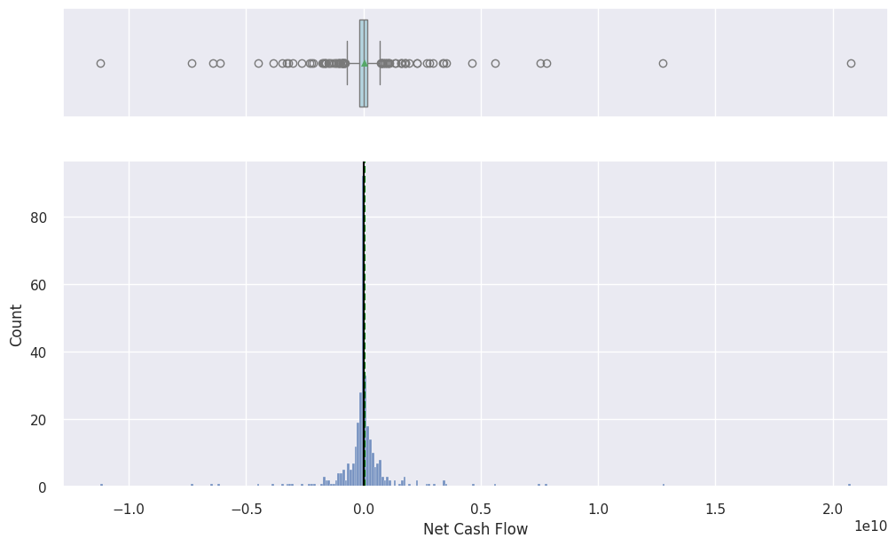

```python
histogram_boxplot(df, 'Net Cash Flow')
```

**Observations:**

- Net cash shows a normal distribution with some outliers to both sides. Outliers are being kept for the analysis.

#### **`Net Income`**

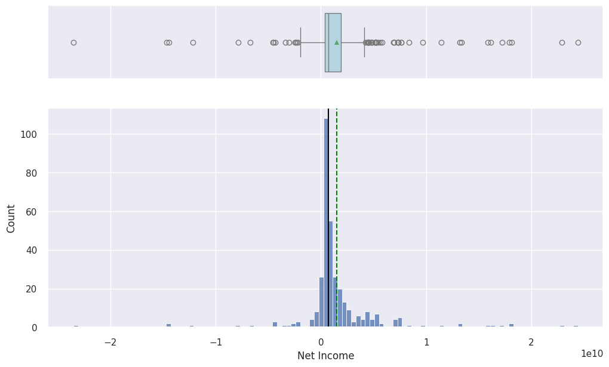

```python
histogram_boxplot(df, 'Net Income')
```

**Observations:**

- Net income shows a normal distribution with some outliers to both sides. Outliers are being kept for the analysis.

#### **`Earnings Per Share`**

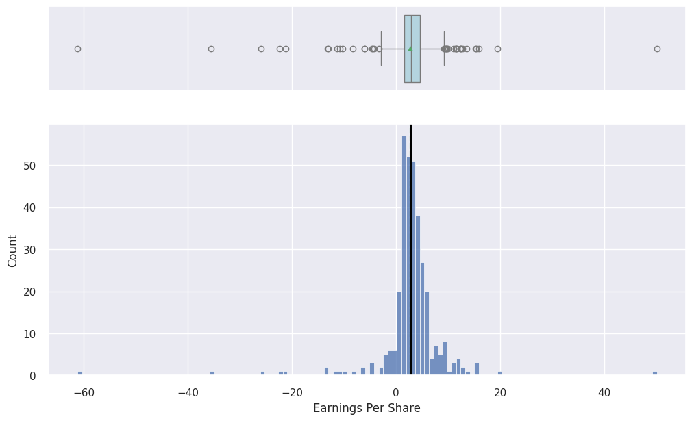

```python
histogram_boxplot(df, 'Earnings Per Share')
```

**Observations:**

- Earnings per share shows a normal distribution with some outliers to both sides. Outliers are being kept for the analysis.

#### **`Estimated Shares Outstanding`**

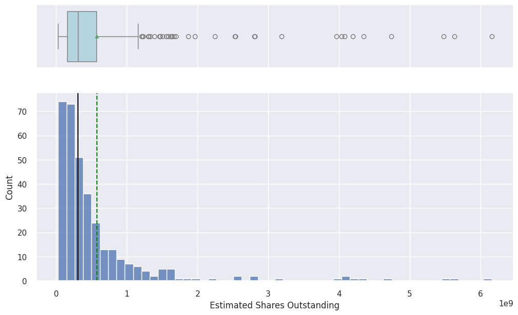

```python
histogram_boxplot(df, 'Estimated Shares Outstanding')
```

**Observations:**

- Estimated shared is skewed to the right with some outliers to the right that will be used for the analysis.

#### **`P/E Ratio`**

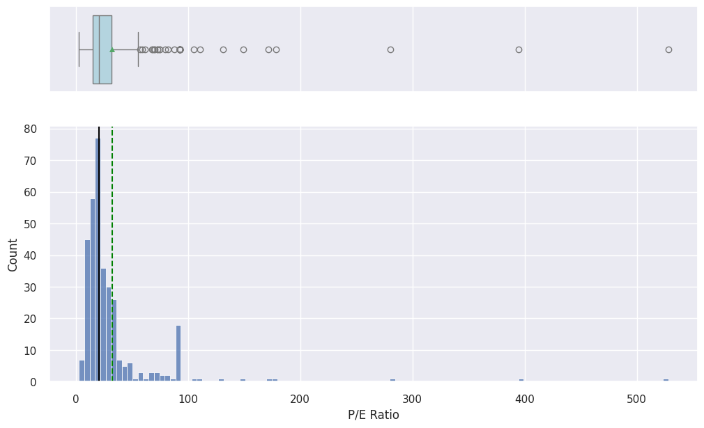

```python
histogram_boxplot(df, 'P/E Ratio')
```

**Observations:**

- P/E ratio change follows a normal distribution with slight skeweness to the right. It has some outliers that will be kept as the bring value to the analysis.

#### **`P/B Ratio`**

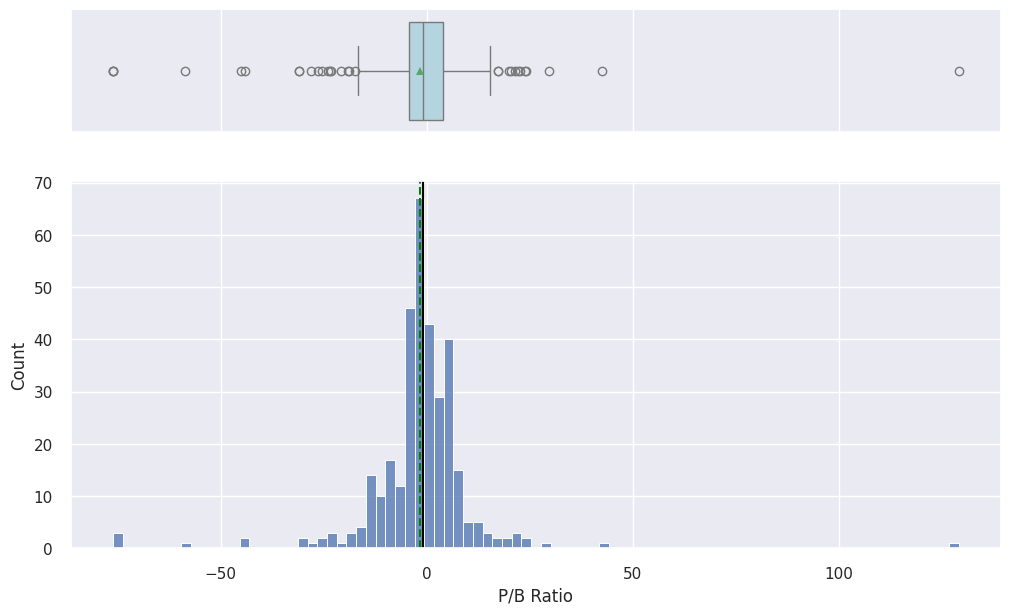

```python
histogram_boxplot(df, 'P/B Ratio')
```

**Observations:**

- P/B ratio hows a clear normal distribution with some outliers that will be used in the analysis.

#### **`GICS Sector`**

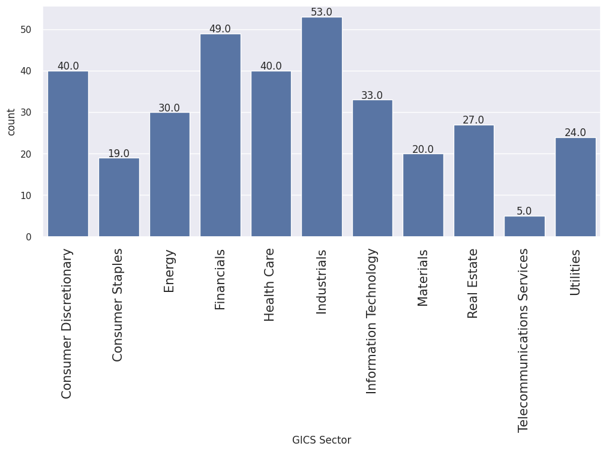

```python
labeled_barplot(df, 'GICS Sector', perc='true')
```

**Observations:**

- The dataset comes with a good variety of data with the exception of Telecommunication services that there are only a handful.

#### **`GICS Sub Industry`**

[figure not shown]

```python
labeled_barplot(df, 'GICS Sub Industry')
```

**Observations:**

- GICS comes with a lot of variety and the dataset is well mixed.

### Bivariate Analysis

#### **`Correlation Check`**

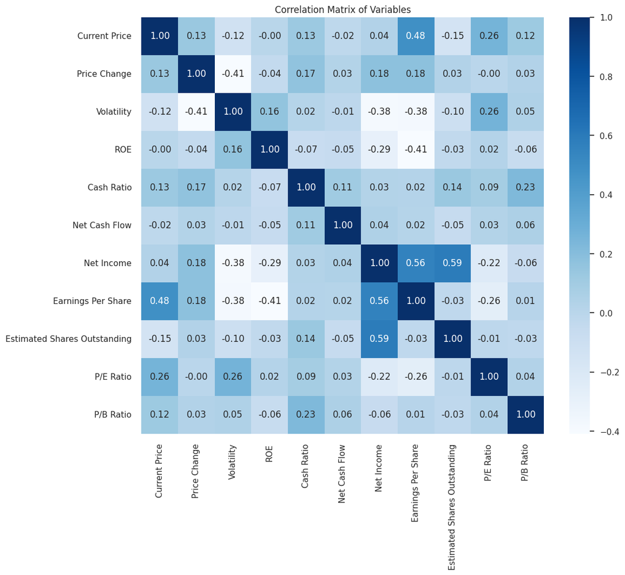

```python
# correlation check
# Select only numeric columns for correlation matrix
numeric_df = df.select_dtypes(include=[np.number])

# Calculate the correlation matrix on numeric columns only
corr = numeric_df.corr()

# Heatmap
plt.figure(figsize=(12, 10))
sns.heatmap(corr, annot=True, cmap='Blues', fmt='.2f')
plt.title('Correlation Matrix of Variables')
plt.show()
```

**Observations:**

- There are no huge correlation between the different variables in the dataset.

#### **`Stocks of which economic sector have seen the maximum price increase on average`**

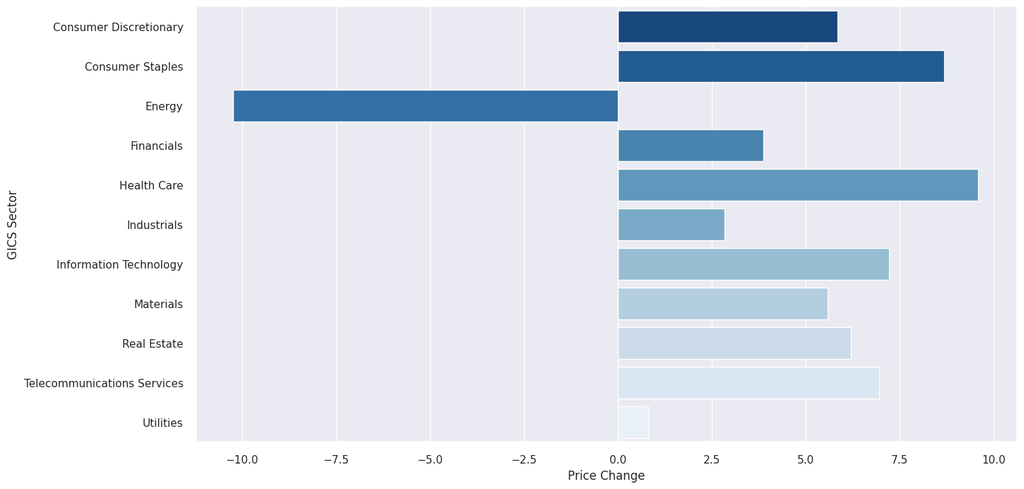

```python
plt.figure(figsize=(15,8))
sns.barplot(data=df, x='Price Change', y='GICS Sector', ci=False, palette='Blues_r')
plt.show()
```

**Observations:**

- Health care and consumer staples are the sectors that have seen the most price increase on average. In other hand, Energy has seen a big drop in value on average.

#### **`How Does the Average Cash Ratio Vary Across Economic Sectors`**

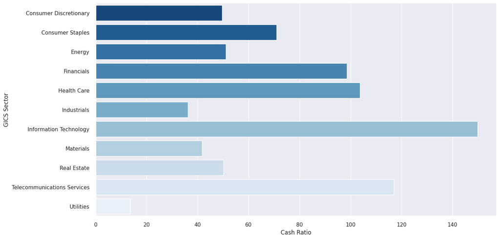

```python
plt.figure(figsize=(15,8))
sns.barplot(data=df, x='Cash Ratio', y='GICS Sector', ci=False, palette='Blues_r')
plt.show()
```

**Observations:**

- IT and telecomm services are the 2 sectors that show the largest cash ratio changes on average.

#### **`How Does the P/E Ratio Vary, on Average, Across Economic Sectors?`**

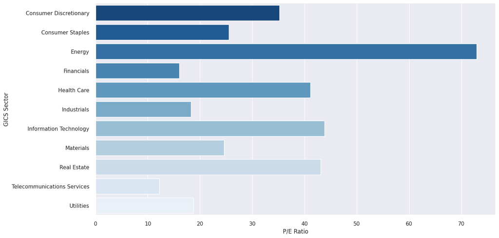

```python
plt.figure(figsize=(15,8))
sns.barplot(data=df, x='P/E Ratio', y='GICS Sector', ci=False, palette='Blues_r')
plt.show()
```

**Observations:**

- Energy, IT and real state services are the sectors that show the P/E ratio changes on average.

#### **`How volatility varies, on average, across economic sectors?`**

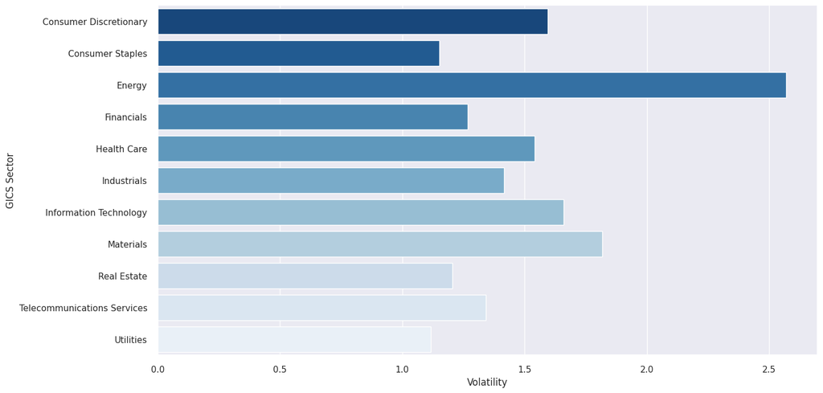

```python
plt.figure(figsize=(15,8))
sns.barplot(data=df, x='Volatility', y='GICS Sector', ci=False, palette='Blues_r')
plt.show()
```

**Observations:**

- Energy and Materials have had the largest volatility changes on average.

## Data Preprocessing

- Outlier check

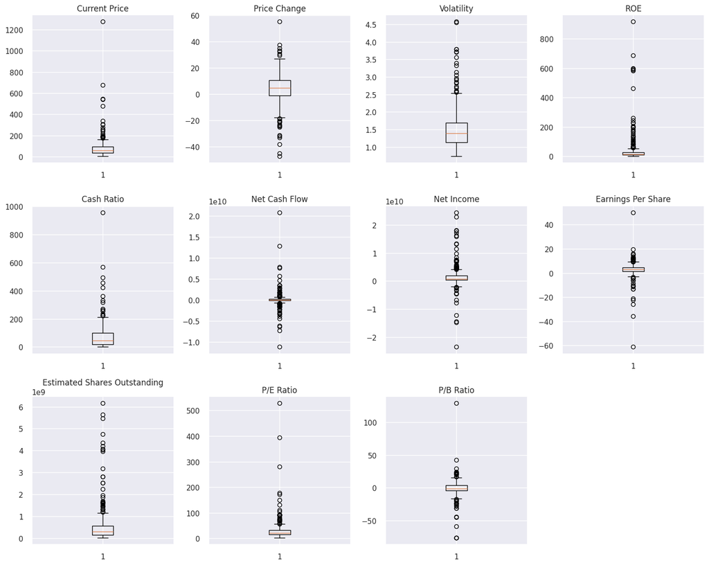

```python
plt.figure(figsize=(15, 12))

numeric_columns = df.select_dtypes(include=np.number).columns.tolist()

for i, variable in enumerate(numeric_columns):
    plt.subplot(3, 4, i + 1)
    plt.boxplot(df[variable], whis=1.5)
    plt.tight_layout()
    plt.title(variable)

plt.show()
```

Observations:

- In the numerival values in the DS, it is interesting to now how a big portion of the earnings per share are very close to 0 and there are many that present negative values.
- Some others show values close to 0 which is important to consider while doing analysis. P/E Ratio, P/B ratio and net cash flow are examples of this behaviour.

### Data Scaling before Clustering

Selecting only numerical values

```python
num_cols = df.select_dtypes(include = np.number).columns.tolist()
```

Scaling process

```python
scaler = StandardScaler()
subset = df[num_cols].copy()
subset_scaled = scaler.fit_transform(subset)
```

Creating dataframe of the scaled data

```python
subset_scaled_df = pd.DataFrame(subset_scaled, columns = subset.columns)
```

Checking data

```python
subset_scaled_df.head()
```

|  | Current Price | Price Change | Volatility | ROE | Cash Ratio | Net Cash Flow | Net Income | Earnings Per Share | Estimated Shares Outstanding | P/E Ratio | P/B Ratio |
| --- | --- | --- | --- | --- | --- | --- | --- | --- | --- | --- | --- |
| 0 | -0.393341 | 0.493950 | 0.272749 | 0.989601 | -0.210698 | -0.339355 | 1.554415 | 1.309399 | 0.107863 | -0.652487 | -0.506653 |
| 1 | -0.220837 | 0.355439 | 1.137045 | 0.937737 | 0.077269 | -0.002335 | 0.927628 | 0.056755 | 1.250274 | -0.311769 | -0.504205 |
| 2 | -0.367195 | 0.602479 | -0.427007 | -0.192905 | -0.033488 | 0.454058 | 0.744371 | 0.024831 | 1.098021 | -0.391502 | 0.094941 |
| 3 | 0.133567 | 0.825696 | -0.284802 | -0.317379 | 1.218059 | -0.152497 | -0.219816 | -0.230563 | -0.091622 | 0.947148 | 0.424333 |
| 4 | -0.260874 | -0.492636 | 0.296470 | -0.265515 | 2.237018 | 0.133564 | -0.202703 | -0.374982 | 1.978399 | 3.293307 | 0.199196 |

## K-means Clustering

### Elbow Plot

```python
k_means_df = subset_scaled_df.copy()
```

```
Number of Clusters: 1 	Average Distortion: 2.5425069919221697
Number of Clusters: 2 	Average Distortion: 2.3862098789299604
Number of Clusters: 3 	Average Distortion: 2.33620927590848
Number of Clusters: 4 	Average Distortion: 2.219050563833442
Number of Clusters: 5 	Average Distortion: 2.133404401901685
Number of Clusters: 6 	Average Distortion: 2.081503686093715
Number of Clusters: 7 	Average Distortion: 2.0045413402786814
Number of Clusters: 8 	Average Distortion: 1.9864237824874411
Number of Clusters: 9 	Average Distortion: 1.956222103389025
Number of Clusters: 10 	Average Distortion: 1.9360473996664198
Number of Clusters: 11 	Average Distortion: 1.8615942883461607
Number of Clusters: 12 	Average Distortion: 1.8219574388532505
Number of Clusters: 13 	Average Distortion: 1.7936924742607907
Number of Clusters: 14 	Average Distortion: 1.7567842179093438
```

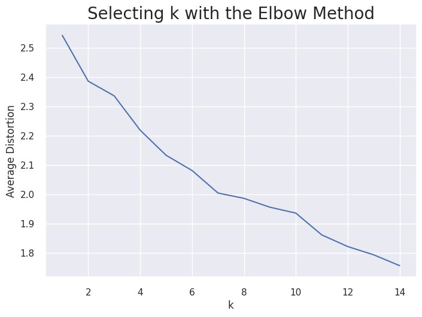

```python
clusters = range(1, 15)
meanDistortions = []

for k in clusters:
    model = KMeans(n_clusters=k, random_state=1)
    model.fit(subset_scaled_df)
    prediction = model.predict(k_means_df)
    distortion = (
        sum(np.min(cdist(k_means_df, model.cluster_centers_, "euclidean"), axis=1))
        / k_means_df.shape[0]
    )

    meanDistortions.append(distortion)

    print("Number of Clusters:", k, "\tAverage Distortion:", distortion)

plt.plot(clusters, meanDistortions, "bx-")
plt.xlabel("k")
plt.ylabel("Average Distortion")
plt.title("Selecting k with the Elbow Method", fontsize=20)
plt.show()
```

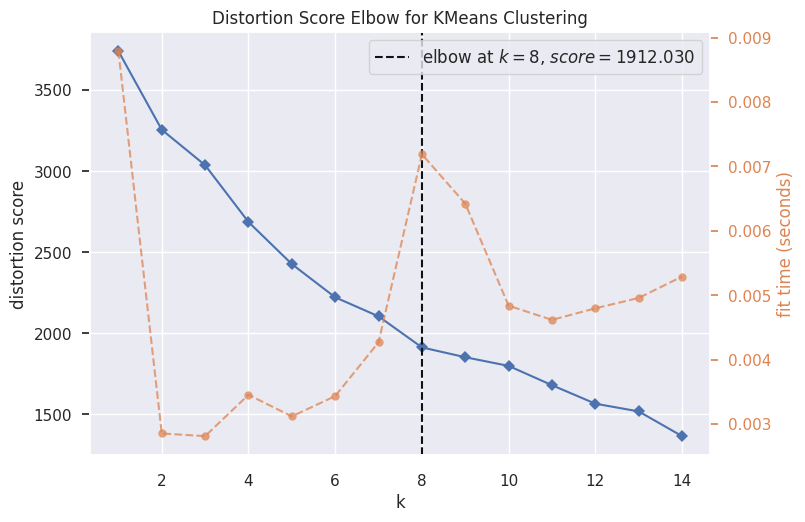

```python
model = KMeans(random_state=1)
visualizer = KElbowVisualizer(model, k=(1, 15), timings=True)
visualizer.fit(k_means_df)  # fit the data to the visualizer
visualizer.show()  # finalize and render figure
```

**Observations:**

- Elbow method shows 8 as the best value to use for clustering.

### Determine k Using the Silhouette Score

```
For n_clusters = 2, the silhouette score is 0.45335782729503565)
For n_clusters = 3, the silhouette score is 0.40374060030338865)
For n_clusters = 4, the silhouette score is 0.4246430808437099)
For n_clusters = 5, the silhouette score is 0.4381539778147092)
For n_clusters = 6, the silhouette score is 0.40869599703024256)
For n_clusters = 7, the silhouette score is 0.1207450219233897)
For n_clusters = 8, the silhouette score is 0.3693991650696542)
For n_clusters = 9, the silhouette score is 0.35185096182499204)
For n_clusters = 10, the silhouette score is 0.32950073703610283)
For n_clusters = 11, the silhouette score is 0.1486586842527321)
For n_clusters = 12, the silhouette score is 0.15784241071085106)
For n_clusters = 13, the silhouette score is 0.15646997458716602)
For n_clusters = 14, the silhouette score is 0.16253506827999134)
```

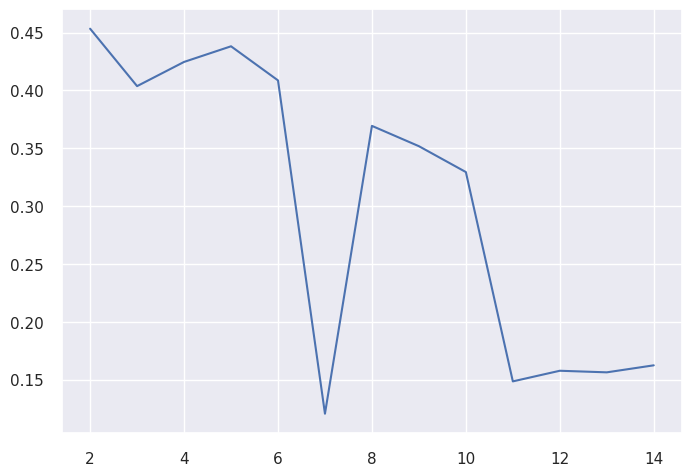

```python
sil_score = []
cluster_list = range(2, 15)
for n_clusters in cluster_list:
    clusterer = KMeans(n_clusters=n_clusters, random_state=1)
    preds = clusterer.fit_predict((subset_scaled_df))
    score = silhouette_score(k_means_df, preds)
    sil_score.append(score)
    print("For n_clusters = {}, the silhouette score is {})".format(n_clusters, score))

plt.plot(cluster_list, sil_score)
plt.show()
```

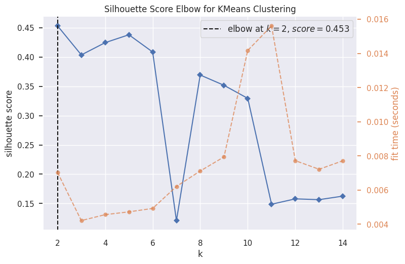

```python
model = KMeans(random_state=1)
visualizer = KElbowVisualizer(model, k=(2, 15), metric="silhouette", timings=True)
visualizer.fit(k_means_df)  # fit the data to the visualizer
visualizer.show()  # finalize and render figure
```

Observations:

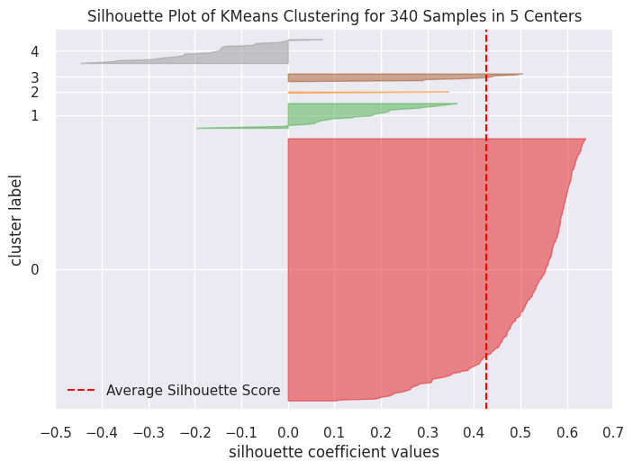

```python
visualizer = SilhouetteVisualizer(KMeans(n_clusters=5, random_state=1))
visualizer.fit(k_means_df)
visualizer.show()
```

- An average score around 0.43 is looking good. Still will test with 6 and 8 to review how clusters look like.

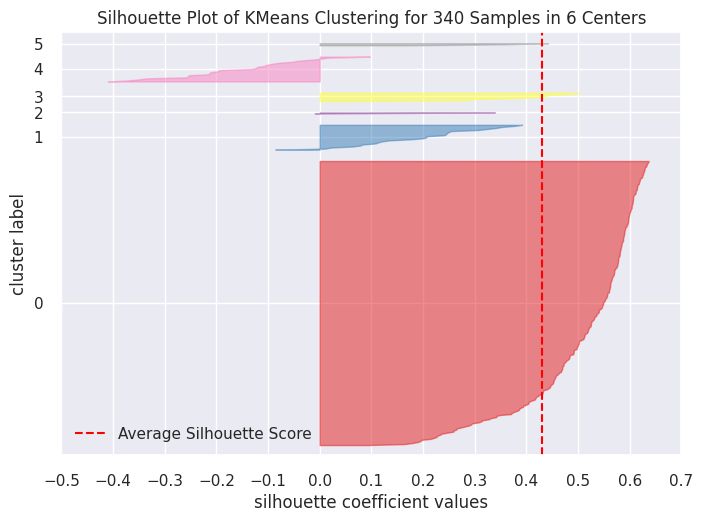

```python
visualizer = SilhouetteVisualizer(KMeans(n_clusters=6, random_state=1))
visualizer.fit(k_means_df)
visualizer.show()
```

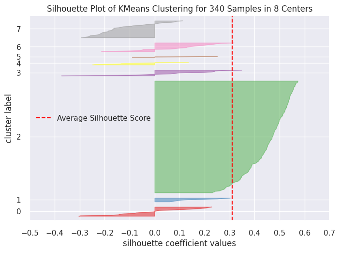

```python
visualizer = SilhouetteVisualizer(KMeans(n_clusters=8, random_state=1))
visualizer.fit(k_means_df)
visualizer.show()
```

**Observations:**

### Creating final model.

```python
kmeans = KMeans(n_clusters=5, random_state=1)
kmeans.fit(k_means_df)
```

```
KMeans(n_clusters=5, random_state=1)
```

```python
# Creating a copy of the original data
dfK = df.copy()

# Adding Kmeans cluster labels to the original and scaled dataframes
k_means_df['KM_segments'] = kmeans.labels_
dfK['KM_segments'] = kmeans.labels_
```

```python
dfK['KM_segments'].info()
```

```
<class 'pandas.core.series.Series'>
RangeIndex: 340 entries, 0 to 339
Series name: KM_segments
Non-Null Count  Dtype
--------------  -----
340 non-null    int32
dtypes: int32(1)
memory usage: 1.5 KB
```

```python
dfK.head(10)
```

|  | Ticker Symbol | Security | GICS Sector | GICS Sub Industry | Current Price | Price Change | Volatility | ROE | Cash Ratio | Net Cash Flow | Net Income | Earnings Per Share | Estimated Shares Outstanding | P/E Ratio | P/B Ratio | KM_segments |
| --- | --- | --- | --- | --- | --- | --- | --- | --- | --- | --- | --- | --- | --- | --- | --- | --- |
| 0 | AAL | American Airlines Group | Industrials | Airlines | 42.349998 | 9.999995 | 1.687151 | 135 | 51 | -604000000 | 7610000000 | 11.39 | 6.681299e+08 | 3.718174 | -8.784219 | 0 |
| 1 | ABBV | AbbVie | Health Care | Pharmaceuticals | 59.240002 | 8.339433 | 2.197887 | 130 | 77 | 51000000 | 5144000000 | 3.15 | 1.633016e+09 | 18.806350 | -8.750068 | 0 |
| 2 | ABT | Abbott Laboratories | Health Care | Health Care Equipment | 44.910000 | 11.301121 | 1.273646 | 21 | 67 | 938000000 | 4423000000 | 2.94 | 1.504422e+09 | 15.275510 | -0.394171 | 0 |
| 3 | ADBE | Adobe Systems Inc | Information Technology | Application Software | 93.940002 | 13.977195 | 1.357679 | 9 | 180 | -240840000 | 629551000 | 1.26 | 4.996437e+08 | 74.555557 | 4.199651 | 0 |
| 4 | ADI | Analog Devices, Inc. | Information Technology | Semiconductors | 55.320000 | -1.827858 | 1.701169 | 14 | 272 | 315120000 | 696878000 | 0.31 | 2.247994e+09 | 178.451613 | 1.059810 | 4 |
| 5 | ADM | Archer-Daniels-Midland Co | Consumer Staples | Agricultural Products | 36.680000 | -12.017268 | 1.516493 | 10 | 49 | -189000000 | 1849000000 | 2.99 | 6.183946e+08 | 12.267559 | 7.496831 | 0 |
| 6 | ADS | Alliance Data Systems | Information Technology | Data Processing & Outsourced Services | 276.570007 | 6.189286 | 1.116976 | 30 | 25 | 90885000 | 596541000 | 8.91 | 6.695185e+07 | 31.040405 | 129.064585 | 4 |
| 7 | AEE | Ameren Corp | Utilities | MultiUtilities | 43.230000 | 2.174424 | 1.124186 | 9 | 14 | 287000000 | 636000000 | 2.60 | 2.446154e+08 | 16.626923 | -0.719497 | 0 |
| 8 | AEP | American Electric Power | Utilities | Electric Utilities | 58.270000 | 2.371753 | 1.068485 | 11 | 9 | 13900000 | 2052300000 | 3.13 | 4.218978e+08 | 18.456543 | -3.022649 | 0 |
| 9 | AFL | AFLAC Inc | Financials | Life & Health Insurance | 59.900002 | 3.027181 | 1.048295 | 14 | 99 | -308000000 | 2533000000 | 5.88 | 4.307823e+08 | 10.187075 | -1.883912 | 0 |

```python
dfK.describe()
```

|  | Current Price | Price Change | Volatility | ROE | Cash Ratio | Net Cash Flow | Net Income | Earnings Per Share | Estimated Shares Outstanding | P/E Ratio | P/B Ratio | KM_segments |
| --- | --- | --- | --- | --- | --- | --- | --- | --- | --- | --- | --- | --- |
| count | 340.000000 | 340.000000 | 340.000000 | 340.000000 | 340.000000 | 3.400000e+02 | 3.400000e+02 | 340.000000 | 3.400000e+02 | 340.000000 | 340.000000 | 340.000000 |
| mean | 80.862345 | 4.078194 | 1.525976 | 39.597059 | 70.023529 | 5.553762e+07 | 1.494385e+09 | 2.776662 | 5.770283e+08 | 32.612563 | -1.718249 | 0.476471 |
| std | 98.055086 | 12.006338 | 0.591798 | 96.547538 | 90.421331 | 1.946365e+09 | 3.940150e+09 | 6.587779 | 8.458496e+08 | 44.348731 | 13.966912 | 1.158287 |
| min | 4.500000 | -47.129693 | 0.733163 | 1.000000 | 0.000000 | -1.120800e+10 | -2.352800e+10 | -61.200000 | 2.767216e+07 | 2.935451 | -76.119077 | 0.000000 |
| 25% | 38.555000 | -0.939484 | 1.134878 | 9.750000 | 18.000000 | -1.939065e+08 | 3.523012e+08 | 1.557500 | 1.588482e+08 | 15.044653 | -4.352056 | 0.000000 |
| 50% | 59.705000 | 4.819505 | 1.385593 | 15.000000 | 47.000000 | 2.098000e+06 | 7.073360e+08 | 2.895000 | 3.096751e+08 | 20.819876 | -1.067170 | 0.000000 |
| 75% | 92.880001 | 10.695493 | 1.695549 | 27.000000 | 99.000000 | 1.698108e+08 | 1.899000e+09 | 4.620000 | 5.731175e+08 | 31.764755 | 3.917066 | 0.000000 |
| max | 1274.949951 | 55.051683 | 4.580042 | 917.000000 | 958.000000 | 2.076400e+10 | 2.444200e+10 | 50.090000 | 6.159292e+09 | 528.039074 | 129.064585 | 4.000000 |

### Cluster Profiling

```python
km_cluster_profile = dfK.groupby('KM_segments').mean(numeric_only = True)
```

```python
km_cluster_profile['count_in_each_segment'] = (
    dfK.groupby("KM_segments")["Security"].count().values
)
```

```python
km_cluster_profile.style.highlight_max(color = 'lightgreen', axis = 0)
```

| KM_segments | Current Price | Price Change | Volatility | ROE | Cash Ratio | Net Cash Flow | Net Income | Earnings Per Share | Estimated Shares Outstanding | P/E Ratio | P/B Ratio | count_in_each_segment |
| --- | --- | --- | --- | --- | --- | --- | --- | --- | --- | --- | --- | --- |
| 0 | 72.841355 | 5.170873 | 1.381148 | 35.054348 | 53.481884 | 121362.318841 | 1548856637.681159 | 3.667808 | 441678653.226848 | 23.624755 | -3.371505 | 276 |
| 1 | 38.194074 | -15.163792 | 2.832583 | 48.148148 | 48.777778 | -104439592.592593 | -2427850333.333333 | -6.262222 | 480223773.242222 | 89.543050 | 1.347101 | 27 |
| 2 | 24.485001 | -13.351992 | 3.482611 | 802.000000 | 51.000000 | -1292500000.000000 | -19106500000.000000 | -41.815000 | 519573983.250000 | 60.748608 | 1.565141 | 2 |
| 3 | 46.672222 | 5.166566 | 1.079367 | 25.000000 | 58.333333 | -3040666666.666667 | 14848444444.444445 | 3.435556 | 4564959946.222222 | 15.596051 | -6.354193 | 9 |
| 4 | 226.489357 | 13.425086 | 1.710605 | 25.346154 | 273.192308 | 1985390923.076923 | 1951357384.615385 | 5.905385 | 738326814.835385 | 72.627508 | 14.000626 | 26 |

```python
for cl in dfK['KM_segments'].unique():
    print('There are total of', dfK[dfK["KM_segments"] == cl]['Security'].nunique(), 'companies in cluster {}, the following companies are present:'.format(cl))
    print(dfK[dfK["KM_segments"] == cl]['Security'].unique())
    print("=" * 100, "\n")
    print()
```

```
There are total of 276 companies in cluster 0, the following companies are present:
['American Airlines Group', 'AbbVie', 'Abbott Laboratories', 'Adobe Systems Inc', 'Archer-Daniels-Midland Co', ..., 'Xylem Inc.', 'Yum! Brands Inc', 'Zimmer Biomet Holdings', 'Zions Bancorp', 'Zoetis']
Length: 276
Categories (340, object): ['3M Company', 'AFLAC Inc', 'AMETEK Inc', 'AT&T Inc', ...,
                           'Zimmer Biomet Holdings', 'Zions Bancorp', 'Zoetis', 'eBay Inc.']
====================================================================================================


There are total of 26 companies in cluster 4, the following companies are present:
['Analog Devices, Inc.', 'Alliance Data Systems', 'Alexion Pharmaceuticals', 'Amgen Inc', 'Amazon.com Inc', ..., 'TripAdvisor', 'Vertex Pharmaceuticals Inc', 'Waters Corporation', 'Wynn Resorts Ltd', 'Yahoo Inc.']
Length: 26
Categories (340, object): ['3M Company', 'AFLAC Inc', 'AMETEK Inc', 'AT&T Inc', ...,
                           'Zimmer Biomet Holdings', 'Zions Bancorp', 'Zoetis', 'eBay Inc.']
====================================================================================================


There are total of 2 companies in cluster 2, the following companies are present:
['Apache Corporation', 'Chesapeake Energy']
Categories (340, object): ['3M Company', 'AFLAC Inc', 'AMETEK Inc', 'AT&T Inc', ...,
                           'Zimmer Biomet Holdings', 'Zions Bancorp', 'Zoetis', 'eBay Inc.']
====================================================================================================


There are total of 27 companies in cluster 1, the following companies are present:
['Anadarko Petroleum Corp', 'Baker Hughes Inc', 'Cabot Oil & Gas', 'Concho Resources', 'Devon Energy Corp.', ..., 'Spectra Energy Corp.', 'Southwestern Energy', 'Teradata Corp.', 'Williams Cos.', 'Cimarex Energy']
Length: 27
Categories (340, object): ['3M Company', 'AFLAC Inc', 'AMETEK Inc', 'AT&T Inc', ...,
                           'Zimmer Biomet Holdings', 'Zions Bancorp', 'Zoetis', 'eBay Inc.']
====================================================================================================


There are total of 9 companies in cluster 3, the following companies are present:
['Citigroup Inc.', 'Ford Motor', 'JPMorgan Chase & Co.', 'Coca Cola Company', 'Pfizer Inc.', 'AT&T Inc', 'Verizon Communications', 'Wells Fargo', 'Exxon Mobil Corp.']
Categories (340, object): ['3M Company', 'AFLAC Inc', 'AMETEK Inc', 'AT&T Inc', ...,
                           'Zimmer Biomet Holdings', 'Zions Bancorp', 'Zoetis', 'eBay Inc.']
====================================================================================================
```

```python
dfK.groupby(["KM_segments", "GICS Sector"])["Security"].count()
```

| KM_segments | GICS Sector | Security |
| --- | --- | --- |
| 0 | Consumer Discretionary | 33 |
|  | Consumer Staples | 17 |
|  | Energy | 5 |
|  | Financials | 45 |
|  | Health Care | 30 |
|  | Industrials | 52 |
|  | Information Technology | 24 |
|  | Materials | 18 |
|  | Real Estate | 26 |
|  | Telecommunications Services | 2 |
|  | Utilities | 24 |
| 1 | Consumer Discretionary | 0 |
|  | Consumer Staples | 0 |
|  | Energy | 21 |
|  | Financials | 0 |
|  | Health Care | 0 |
|  | Industrials | 1 |
|  | Information Technology | 3 |
|  | Materials | 2 |
|  | Real Estate | 0 |
|  | Telecommunications Services | 0 |
|  | Utilities | 0 |
| 2 | Consumer Discretionary | 0 |
|  | Consumer Staples | 0 |
|  | Energy | 2 |
|  | Financials | 0 |
|  | Health Care | 0 |
|  | Industrials | 0 |
|  | Information Technology | 0 |
|  | Materials | 0 |
|  | Real Estate | 0 |
|  | Telecommunications Services | 0 |
|  | Utilities | 0 |
| 3 | Consumer Discretionary | 1 |
|  | Consumer Staples | 1 |
|  | Energy | 1 |
|  | Financials | 3 |
|  | Health Care | 1 |
|  | Industrials | 0 |
|  | Information Technology | 0 |
|  | Materials | 0 |
|  | Real Estate | 0 |
|  | Telecommunications Services | 2 |
|  | Utilities | 0 |
| 4 | Consumer Discretionary | 6 |
|  | Consumer Staples | 1 |
|  | Energy | 1 |
|  | Financials | 1 |
|  | Health Care | 9 |
|  | Industrials | 0 |
|  | Information Technology | 6 |
|  | Materials | 0 |
|  | Real Estate | 1 |
|  | Telecommunications Services | 1 |
|  | Utilities | 0 |

**dtype:** int64

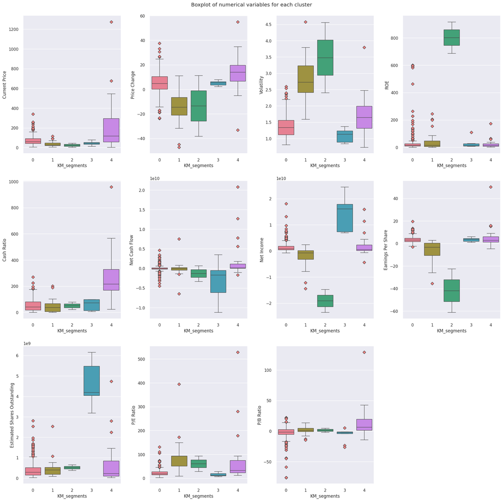

```python
plt.figure(figsize = (20,20))
plt.suptitle("Boxplot of numerical variables for each cluster")

# To select numerical columns
num_col = df.select_dtypes(include = np.number).columns.tolist()
for i, variable in enumerate(num_col):
    plt.subplot(3, 4, i + 1)
    sns.boxplot(data = dfK, x = "KM_segments", y = variable, palette = 'husl', flierprops = dict(markerfacecolor='lightcoral', marker = 'D'))

plt.tight_layout(pad = 2.0)
```

```python
# Generate a color map with a unique color for each bar
num_of_bars = len(dfK.columns) - 1  # Subtract 1 for the GROUP column
cm = plt.get_cmap('tab10')
colors = [cm(1. * i / num_of_bars) for i in range(num_of_bars)]
```

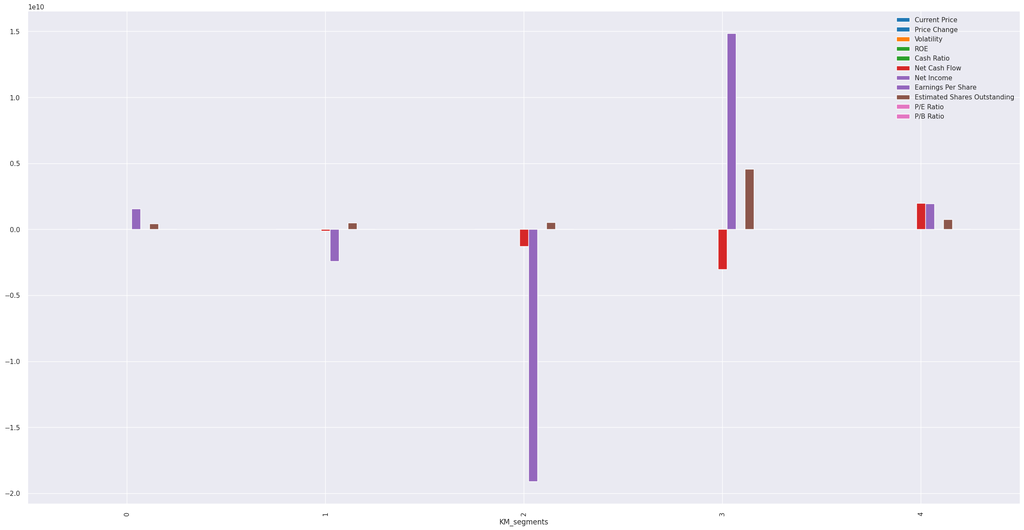

```python
dfK.groupby("KM_segments").mean(numeric_only = True).plot.bar(figsize = (30,15), color = colors)
```

## Hierarchical Clustering

### Cophenetic Correlation

```python
hc_df = subset_scaled_df.copy()
```

```python
# List of distance metrics
distance_metrics = ['euclidean', 'chebyshev', 'mahalanobis', 'cityblock']

# List of linkage methods
linkage_methods = ['single', 'complete', 'average', 'weighted']

high_cophenet_corr = 0
high_dm_lm = [0,0]

for dm in distance_metrics:
    for lm in linkage_methods:
        Z = linkage(hc_df, metric = dm, method = lm)
        c, coph_dists = cophenet(Z, pdist(hc_df))
        print(
            "Cophenetic correlation for {} distance and {} linkage is {}.".format(dm.capitalize(), lm, c)
        )
        if high_cophenet_corr < c:
            high_cophenet_corr = c
            high_dm_lm[0] = dm
            high_dm_lm[1] = lm


# Printing the combination of distance metric and linkage method with the highest cophenetic correlation
print('***'*50)

print(
    "Highest cophenetic correlation is {}, which is obtained with {} distance and {} linkage".format(high_cophenet_corr,
                                                                                                     high_dm_lm[0].capitalize(),
                                                                                                     high_dm_lm[1])
)
```

```
Cophenetic correlation for Euclidean distance and single linkage is 0.9232271494002922.
Cophenetic correlation for Euclidean distance and complete linkage is 0.7873280186580672.
Cophenetic correlation for Euclidean distance and average linkage is 0.9422540609560814.
Cophenetic correlation for Euclidean distance and weighted linkage is 0.8693784298129404.
Cophenetic correlation for Chebyshev distance and single linkage is 0.9062538164750717.
Cophenetic correlation for Chebyshev distance and complete linkage is 0.598891419111242.
Cophenetic correlation for Chebyshev distance and average linkage is 0.9338265528030499.
Cophenetic correlation for Chebyshev distance and weighted linkage is 0.9127355892367.
Cophenetic correlation for Mahalanobis distance and single linkage is 0.925919553052459.
Cophenetic correlation for Mahalanobis distance and complete linkage is 0.7925307202850002.
Cophenetic correlation for Mahalanobis distance and average linkage is 0.9247324030159736.
Cophenetic correlation for Mahalanobis distance and weighted linkage is 0.8708317490180428.
Cophenetic correlation for Cityblock distance and single linkage is 0.9334186366528574.
Cophenetic correlation for Cityblock distance and complete linkage is 0.7375328863205818.
Cophenetic correlation for Cityblock distance and average linkage is 0.9302145048594667.
Cophenetic correlation for Cityblock distance and weighted linkage is 0.731045513520281.
Highest cophenetic correlation is 0.9422540609560814, which is obtained with Euclidean distance and average linkage
```

**Explore different linkage methods with Euclidean distance only.**

```python
# list of linkage methods
linkage_methods = ['single', 'complete', 'average', 'centroid', 'ward', 'weighted']

high_cophenet_corr = 0
high_dm_lm = [0, 0]

for lm in linkage_methods:
    Z = linkage(hc_df, metric="euclidean", method=lm)
    c, coph_dists = cophenet(Z, pdist(hc_df))
    print("Cophenetic correlation for {} linkage is {}.".format(lm, c))
    if high_cophenet_corr < c:
        high_cophenet_corr = c
        high_dm_lm[0] = "euclidean"
        high_dm_lm[1] = lm

# printing the combination of distance metric and linkage method with the highest cophenetic correlation
print('*'*100)
print(
    "Highest cophenetic correlation is {}, which is obtained with {} linkage.".format(
        high_cophenet_corr, high_dm_lm[1]
    )
)
```

```
Cophenetic correlation for single linkage is 0.9232271494002922.
Cophenetic correlation for complete linkage is 0.7873280186580672.
Cophenetic correlation for average linkage is 0.9422540609560814.
Cophenetic correlation for centroid linkage is 0.9314012446828154.
Cophenetic correlation for ward linkage is 0.7101180299865353.
Cophenetic correlation for weighted linkage is 0.8693784298129404.
Highest cophenetic correlation is 0.9422540609560814, which is obtained with average linkage.
```

**Observations:**

- The maximum Cophenetic Correlation is **Euclidean distance** and **average linkage**

### Checking Dendograms

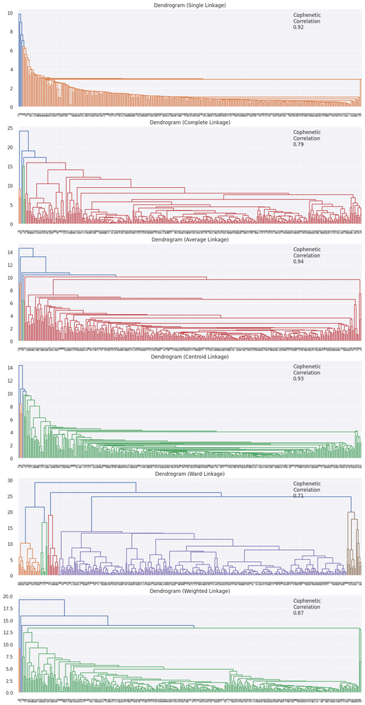

```python
# list of linkage methods
linkage_methods = ['single', 'complete', 'average', 'centroid', 'ward', 'weighted']

# lists to save results of cophenetic correlation calculation
compare_cols = ["Linkage", "Cophenetic Coefficient"]
compare = []

# to create a subplot image
fig, axs = plt.subplots(len(linkage_methods), 1, figsize=(15, 30))

# We will enumerate through the list of linkage methods above
# For each linkage method, we will plot the dendrogram and calculate the cophenetic correlation
for i, method in enumerate(linkage_methods):
    Z = linkage(hc_df, metric="euclidean", method=method)

    dendrogram(Z, ax=axs[i])
    axs[i].set_title(f"Dendrogram ({method.capitalize()} Linkage)")

    coph_corr, coph_dist = cophenet(Z, pdist(hc_df))
    axs[i].annotate(
        f"Cophenetic\nCorrelation\n{coph_corr:0.2f}",
        (0.80, 0.80),
        xycoords="axes fraction",
    )
    compare.append([method, coph_corr])
```

```python
# create and print a dataframe to compare cophenetic correlations for different linkage methods
df_cc = pd.DataFrame(compare, columns = compare_cols)
df_cc = df_cc.sort_values(by="Cophenetic Coefficient")
df_cc
```

|  | Linkage | Cophenetic Coefficient |
| --- | --- | --- |
| 4 | ward | 0.710118 |
| 1 | complete | 0.787328 |
| 5 | weighted | 0.869378 |
| 0 | single | 0.923227 |
| 3 | centroid | 0.931401 |
| 2 | average | 0.942254 |

**Observations**

- The cophenetic correlation is highest for average and centroid linkage methods, but the dendrogram for average appears to provide better clusters
- 5 appears to be the appropriate number of clusters for the average linkage method

### Creating model using sklearn with Euclidean and Average linkage

```python
HCmodel = AgglomerativeClustering(n_clusters = 5,  metric = 'euclidean', linkage = 'average')
HCmodel.fit(hc_df)
```

```
AgglomerativeClustering(linkage='average', n_clusters=5)
```

```python
# creating a copy of the original data
df2 = df.copy()

# adding hierarchical cluster labels to the original and scaled dataframes
hc_df["HC_segments"] = HCmodel.labels_
df2["HC_segments"] = HCmodel.labels_
```

### Cluster Profiling for Euclidean - Average

```python
hc_cluster_profile = df2.groupby("HC_segments").mean(numeric_only = True)
```

```python
hc_cluster_profile['count_in_each_segment'] = (
    df2.groupby("HC_segments")["Security"].count().values
)
```

```python
hc_cluster_profile.style.highlight_max(color="lightgreen", axis=0)
```

| HC_segments | Current Price | Price Change | Volatility | ROE | Cash Ratio | Net Cash Flow | Net Income | Earnings Per Share | Estimated Shares Outstanding | P/E Ratio | P/B Ratio | count_in_each_segment |
| --- | --- | --- | --- | --- | --- | --- | --- | --- | --- | --- | --- | --- |
| 0 | 77.884243 | 4.105986 | 1.516865 | 35.320359 | 66.775449 | -32825817.365269 | 1535255703.592814 | 2.903308 | 559027333.145509 | 32.437511 | -1.781988 | 334 |
| 1 | 25.640000 | 11.237908 | 1.322355 | 12.500000 | 130.500000 | 16755500000.000000 | 13654000000.000000 | 3.295000 | 2791829362.100000 | 13.649696 | 1.508484 | 2 |
| 2 | 24.485001 | -13.351992 | 3.482611 | 802.000000 | 51.000000 | -1292500000.000000 | -19106500000.000000 | -41.815000 | 519573983.250000 | 60.748608 | 1.565141 | 2 |
| 3 | 104.660004 | 16.224320 | 1.320606 | 8.000000 | 958.000000 | 592000000.000000 | 3669000000.000000 | 1.310000 | 2800763359.000000 | 79.893133 | 5.884467 | 1 |
| 4 | 1274.949951 | 3.190527 | 1.268340 | 29.000000 | 184.000000 | -1671386000.000000 | 2551360000.000000 | 50.090000 | 50935516.070000 | 25.453183 | -1.052429 | 1 |

```python
## Complete the code to print the companies in each cluster
for cl in df2["HC_segments"].unique():
    print("In cluster {}, the following companies are present:".format(cl))
    print(df2[df2["HC_segments"] == cl]["Security"].unique())
    print("=" * 100, "\n")
    print()
```

```
In cluster 0, the following companies are present:
['American Airlines Group', 'AbbVie', 'Abbott Laboratories', 'Adobe Systems Inc', 'Analog Devices, Inc.', ..., 'Yahoo Inc.', 'Yum! Brands Inc', 'Zimmer Biomet Holdings', 'Zions Bancorp', 'Zoetis']
Length: 334
Categories (340, object): ['3M Company', 'AFLAC Inc', 'AMETEK Inc', 'AT&T Inc', ...,
                           'Zimmer Biomet Holdings', 'Zions Bancorp', 'Zoetis', 'eBay Inc.']
====================================================================================================


In cluster 2, the following companies are present:
['Apache Corporation', 'Chesapeake Energy']
Categories (340, object): ['3M Company', 'AFLAC Inc', 'AMETEK Inc', 'AT&T Inc', ...,
                           'Zimmer Biomet Holdings', 'Zions Bancorp', 'Zoetis', 'eBay Inc.']
====================================================================================================


In cluster 1, the following companies are present:
['Bank of America Corp', 'Intel Corp.']
Categories (340, object): ['3M Company', 'AFLAC Inc', 'AMETEK Inc', 'AT&T Inc', ...,
                           'Zimmer Biomet Holdings', 'Zions Bancorp', 'Zoetis', 'eBay Inc.']
====================================================================================================


In cluster 3, the following companies are present:
['Facebook']
Categories (340, object): ['3M Company', 'AFLAC Inc', 'AMETEK Inc', 'AT&T Inc', ...,
                           'Zimmer Biomet Holdings', 'Zions Bancorp', 'Zoetis', 'eBay Inc.']
====================================================================================================


In cluster 4, the following companies are present:
['Priceline.com Inc']
Categories (340, object): ['3M Company', 'AFLAC Inc', 'AMETEK Inc', 'AT&T Inc', ...,
                           'Zimmer Biomet Holdings', 'Zions Bancorp', 'Zoetis', 'eBay Inc.']
====================================================================================================
```

```python
df2.groupby(["HC_segments", "GICS Sector"])["Security"].count()
```

| HC_segments | GICS Sector | Security |
| --- | --- | --- |
| 0 | Consumer Discretionary | 39 |
|  | Consumer Staples | 19 |
|  | Energy | 28 |
|  | Financials | 48 |
|  | Health Care | 40 |
|  | Industrials | 53 |
|  | Information Technology | 31 |
|  | Materials | 20 |
|  | Real Estate | 27 |
|  | Telecommunications Services | 5 |
|  | Utilities | 24 |
| 1 | Consumer Discretionary | 0 |
|  | Consumer Staples | 0 |
|  | Energy | 0 |
|  | Financials | 1 |
|  | Health Care | 0 |
|  | Industrials | 0 |
|  | Information Technology | 1 |
|  | Materials | 0 |
|  | Real Estate | 0 |
|  | Telecommunications Services | 0 |
|  | Utilities | 0 |
| 2 | Consumer Discretionary | 0 |
|  | Consumer Staples | 0 |
|  | Energy | 2 |
|  | Financials | 0 |
|  | Health Care | 0 |
|  | Industrials | 0 |
|  | Information Technology | 0 |
|  | Materials | 0 |
|  | Real Estate | 0 |
|  | Telecommunications Services | 0 |
|  | Utilities | 0 |
| 3 | Consumer Discretionary | 0 |
|  | Consumer Staples | 0 |
|  | Energy | 0 |
|  | Financials | 0 |
|  | Health Care | 0 |
|  | Industrials | 0 |
|  | Information Technology | 1 |
|  | Materials | 0 |
|  | Real Estate | 0 |
|  | Telecommunications Services | 0 |
|  | Utilities | 0 |
| 4 | Consumer Discretionary | 1 |
|  | Consumer Staples | 0 |
|  | Energy | 0 |
|  | Financials | 0 |
|  | Health Care | 0 |
|  | Industrials | 0 |
|  | Information Technology | 0 |
|  | Materials | 0 |
|  | Real Estate | 0 |
|  | Telecommunications Services | 0 |
|  | Utilities | 0 |

**dtype:** int64

[figure not shown]

```python
plt.figure(figsize = (20,20))
plt.suptitle("Boxplot of numerical variables for each cluster")

for i, variable in enumerate(num_col):
    plt.subplot(3, 4, i+1)
    sns.boxplot(data = df2, x = "HC_segments", y = variable, palette = 'husl', flierprops = dict(markerfacecolor = 'lightcoral', marker = 'D',))

plt.tight_layout(pad = 2.0)
```

**Insights**

- Cluster 0: There are 334 companies in cluster 0.
- Cluster 1: There are only 2 companies in Cluster 1.
- Cluster 2: There are only 2 companies in Cluster 2.
- Cluster 3: There are only 1 companies in Cluster 3.
- Cluster 4: There are only 1 companies in Cluster 4.

*-* The clustering does not look good since clusters don't have enough variability.

*-* Ward linkage to be used and test if works better. Taken from dendogram.

*-* Using 5 clusters for ward linkage.

### Creating Model using Euclidean distance and Ward linkage

```python
HCmodel = AgglomerativeClustering(n_clusters = 5, metric = 'euclidean', linkage = 'ward')
HCmodel.fit(hc_df)
```

```
AgglomerativeClustering(n_clusters=5)
```

```python
# Creating a copy of the original data for Euclidean Ward
dfHCW = df.copy()

# Adding hierarchical cluster labels to the original and scaled datagrames
hc_df['HC_segments'] = HCmodel.labels_
dfHCW['HC_segments'] = HCmodel.labels_
```

### Cluster Profiling for Euclidean - Ward

```python
hc_cluster_profile = dfHCW.groupby("HC_segments").mean(numeric_only = True)
```

```python
hc_cluster_profile['count_in_each_segment'] = (dfHCW.groupby("HC_segments")["Security"].count().values)
```

```python
hc_cluster_profile.style.highlight_max(color='lightgreen', axis = 0)
```

| HC_segments | Current Price | Price Change | Volatility | ROE | Cash Ratio | Net Cash Flow | Net Income | Earnings Per Share | Estimated Shares Outstanding | P/E Ratio | P/B Ratio | count_in_each_segment |
| --- | --- | --- | --- | --- | --- | --- | --- | --- | --- | --- | --- | --- |
| 0 | 326.198218 | 10.563242 | 1.642560 | 14.400000 | 309.466667 | 288850666.666667 | 864498533.333333 | 7.785333 | 544900261.301333 | 113.095334 | 19.142151 | 15 |
| 1 | 72.432035 | 5.255290 | 1.426349 | 25.512195 | 60.881533 | 196157425.087108 | 1623022236.933798 | 3.652840 | 462816085.049861 | 24.645506 | -2.618234 | 287 |
| 2 | 46.672222 | 5.166566 | 1.079367 | 25.000000 | 58.333333 | -3040666666.666667 | 14848444444.444445 | 3.435556 | 4564959946.222222 | 15.596051 | -6.354193 | 9 |
| 3 | 84.355716 | 3.854981 | 1.827670 | 633.571429 | 33.571429 | -568400000.000000 | -4968157142.857142 | -10.841429 | 398169036.442857 | 42.284541 | -11.589502 | 7 |
| 4 | 36.440455 | -16.073408 | 2.832884 | 57.500000 | 42.409091 | -472834090.909091 | -3161045227.272727 | -8.005000 | 514367806.201818 | 85.555682 | 0.836839 | 22 |

```python
# List the names of companies in each cluster
for cl in dfHCW['HC_segments'].unique():
    print('There are total of', dfHCW[dfHCW['HC_segments'] == cl]['Security'].nunique(), 'companies in cluster {}, the following companies are present:'.format(cl))
    print(dfHCW[dfHCW['HC_segments'] == cl]['Security'].unique())
    print('*' * 100, '\n')
    print()
```

```
There are total of 287 companies in cluster 1, the following companies are present:
['American Airlines Group', 'AbbVie', 'Abbott Laboratories', 'Adobe Systems Inc', 'Analog Devices, Inc.', ..., 'Xylem Inc.', 'Yum! Brands Inc', 'Zimmer Biomet Holdings', 'Zions Bancorp', 'Zoetis']
Length: 287
Categories (340, object): ['3M Company', 'AFLAC Inc', 'AMETEK Inc', 'AT&T Inc', ...,
                           'Zimmer Biomet Holdings', 'Zions Bancorp', 'Zoetis', 'eBay Inc.']


There are total of 15 companies in cluster 0, the following companies are present:
['Alliance Data Systems', 'Alexion Pharmaceuticals', 'Amgen Inc', 'Amazon.com Inc', 'Chipotle Mexican Grill', ..., 'Netflix Inc.', 'Priceline.com Inc', 'Regeneron', 'Waters Corporation', 'Yahoo Inc.']
Length: 15
Categories (340, object): ['3M Company', 'AFLAC Inc', 'AMETEK Inc', 'AT&T Inc', ...,
                           'Zimmer Biomet Holdings', 'Zions Bancorp', 'Zoetis', 'eBay Inc.']


There are total of 7 companies in cluster 3, the following companies are present:
['Allegion', 'Apache Corporation', 'Chesapeake Energy', 'Charter Communications', 'Colgate-Palmolive', 'Kimberly-Clark', 'S&P Global, Inc.']
Categories (340, object): ['3M Company', 'AFLAC Inc', 'AMETEK Inc', 'AT&T Inc', ...,
                           'Zimmer Biomet Holdings', 'Zions Bancorp', 'Zoetis', 'eBay Inc.']


There are total of 22 companies in cluster 4, the following companies are present:
['Anadarko Petroleum Corp', 'Baker Hughes Inc', 'Cabot Oil & Gas', 'Concho Resources', 'Devon Energy Corp.', ..., 'Spectra Energy Corp.', 'Southwestern Energy', 'Teradata Corp.', 'Williams Cos.', 'Cimarex Energy']
Length: 22
Categories (340, object): ['3M Company', 'AFLAC Inc', 'AMETEK Inc', 'AT&T Inc', ...,
                           'Zimmer Biomet Holdings', 'Zions Bancorp', 'Zoetis', 'eBay Inc.']


There are total of 9 companies in cluster 2, the following companies are present:
['Citigroup Inc.', 'Ford Motor', 'JPMorgan Chase & Co.', 'Coca Cola Company', 'Pfizer Inc.', 'AT&T Inc', 'Verizon Communications', 'Wells Fargo', 'Exxon Mobil Corp.']
Categories (340, object): ['3M Company', 'AFLAC Inc', 'AMETEK Inc', 'AT&T Inc', ...,
                           'Zimmer Biomet Holdings', 'Zions Bancorp', 'Zoetis', 'eBay Inc.']
```

```python
dfHCW.groupby(['HC_segments', 'GICS Sector'])['Security'].count()
```

| HC_segments | GICS Sector | Security |
| --- | --- | --- |
| 0 | Consumer Discretionary | 3 |
|  | Consumer Staples | 1 |
|  | Energy | 0 |
|  | Financials | 0 |
|  | Health Care | 5 |
|  | Industrials | 0 |
|  | Information Technology | 4 |
|  | Materials | 0 |
|  | Real Estate | 1 |
|  | Telecommunications Services | 1 |
|  | Utilities | 0 |
| 1 | Consumer Discretionary | 35 |
|  | Consumer Staples | 15 |
|  | Energy | 7 |
|  | Financials | 45 |
|  | Health Care | 34 |
|  | Industrials | 52 |
|  | Information Technology | 28 |
|  | Materials | 19 |
|  | Real Estate | 26 |
|  | Telecommunications Services | 2 |
|  | Utilities | 24 |
| 2 | Consumer Discretionary | 1 |
|  | Consumer Staples | 1 |
|  | Energy | 1 |
|  | Financials | 3 |
|  | Health Care | 1 |
|  | Industrials | 0 |
|  | Information Technology | 0 |
|  | Materials | 0 |
|  | Real Estate | 0 |
|  | Telecommunications Services | 2 |
|  | Utilities | 0 |
| 3 | Consumer Discretionary | 1 |
|  | Consumer Staples | 2 |
|  | Energy | 2 |
|  | Financials | 1 |
|  | Health Care | 0 |
|  | Industrials | 1 |
|  | Information Technology | 0 |
|  | Materials | 0 |
|  | Real Estate | 0 |
|  | Telecommunications Services | 0 |
|  | Utilities | 0 |
| 4 | Consumer Discretionary | 0 |
|  | Consumer Staples | 0 |
|  | Energy | 20 |
|  | Financials | 0 |
|  | Health Care | 0 |
|  | Industrials | 0 |
|  | Information Technology | 1 |
|  | Materials | 1 |
|  | Real Estate | 0 |
|  | Telecommunications Services | 0 |
|  | Utilities | 0 |

**dtype:** int64

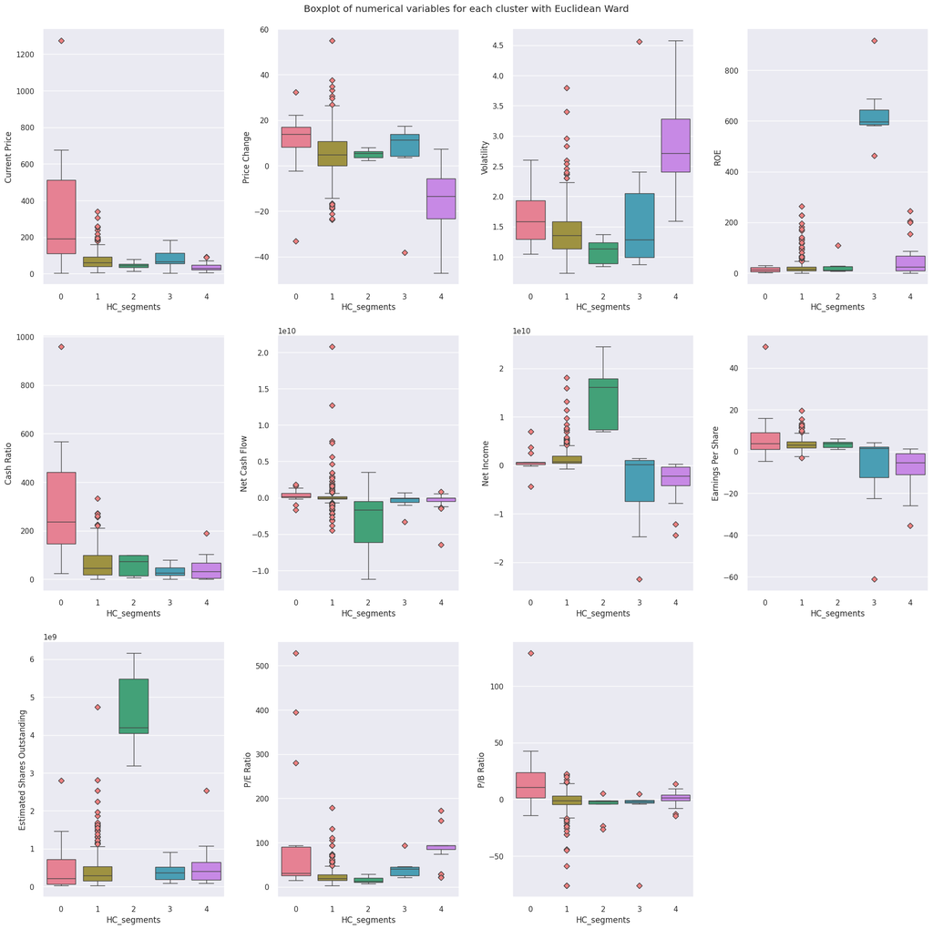

```python
plt.figure(figsize = (20,20))
plt.suptitle("Boxplot of numerical variables for each cluster with Euclidean Ward")

for i, variable in enumerate(num_col):
    plt.subplot(3, 4, i+1)
    sns.boxplot(data = dfHCW, x = 'HC_segments', y = variable, palette = 'husl', flierprops = dict(markerfacecolor = 'lightcoral', marker = 'D',))

plt.tight_layout(pad = 2.0)
```

```python
# Generate a color map with a unique color for each bar
num_of_bars = len(dfHCW.columns) - 1  # Subtract 1 for the GROUP column
cm = plt.get_cmap('tab10')
colors = [cm(1. * i / num_of_bars) for i in range(num_of_bars)]
```

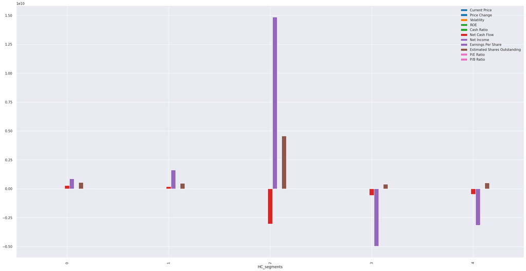

```python
dfHCW.groupby("HC_segments").mean(numeric_only = True).plot.bar(figsize = (30,15), color = colors)
```

**Insights**

- Cluster **0**
  - There are 15 companies in Cluster 0.
  - The stocks in this cluster have the following detailes:
    - Very low net cash flow
    - Low net income
    - Low Estimated shares outstanding
- Cluster **1**
  - There are 287 companies in Cluster 1.
  - The stocks in this cluster have the following detailes:
    - Very Low net cash flow
    - Moderate net income
    - Low Estimated shares outstanding
- Cluster **2**
  - There are 9 companies in Cluster 2.
  - The stocks in this cluster have the following detailes:
    - Negative net cash flow
    - Very High net income
    - High Estimated shares outstanding
- Cluster **3**
  - There are 7 companies in Cluster 3.
  - The stocks in this cluster have the following detailes:
    - Negative Low net cash flow
    - High negative net income
    - Very low Estimated shares outstanding
- Cluster **4**
  - There are 22 companies in Cluster 4.
  - The stocks in this cluster have the following detailes:
    - Negative Low net cash flow
    - Moderate negative net income
    - Very low Estimated shares outstanding

## K-means vs Hierarchical Clustering

- Hierarchical and K-means had almost the same performance in execution, no major differences.
- Both techniques showed two similar clusters and others dissimilar. Ward linkage in Hierarchical showed a better clustering result.
- The groupings using Hierarchical is better than K-means in terms of distribution of companies.
- Both algorithms yielded similar clusters based on the outliers using the variables provided.

## Actionable Insights and Recommendations

**Recommendations:**

- Algorithm Refinement: The difference in cluster suggestions from K-Means and Hierarchical clustering methods indicates a need for algorithm refinement.
- More variables are required to have a better analysis since both methods have one particular cluster with many companies and some others with just a few showing that there's not very good distribution of portfolios.
- As of now, the tool doesn't allow to recommend specific sectors to invest, more analysis needs to be done on this end.

**Insights**

- Trade&Ahead needs to consider their clients' profile and how they want to invest, before suggesting any of the clusters (portfolios) aligned by this tool since in almost all there are risks associated.
- Depending on the client's profile the tool does provide portfolios whith details to take decisions such as net cash and overall shares outstanding.